# Cao_Jinpu_A4

## 3.The over-representation of the Latinx 25+ population who have no college degree

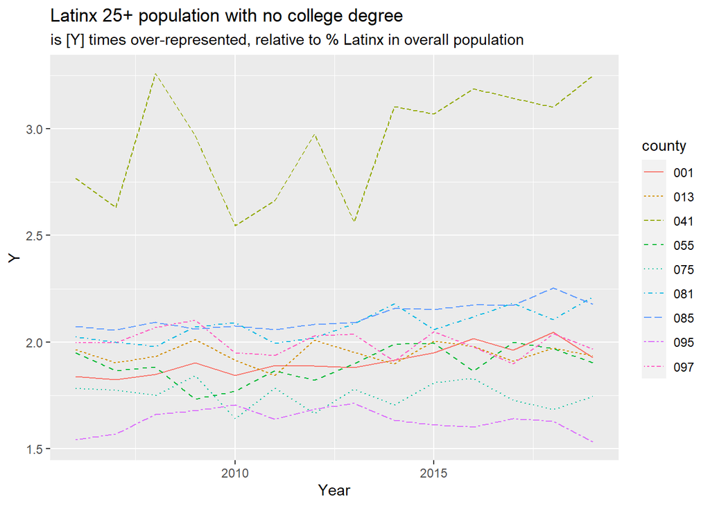

From the chart we can see that the over/under-represention ratios Y (Y = [#Latinx pop with no college degree / # Total pop with no college degree] / [#Latinx pop / # Total pop]) are higher than 1.0 for any county in every year. This shows the eudcation attainment of Latinx population should be paid attention to. For county 041 (Marin County), Y are very high (more than 2.5) and Y are still increasing in recent years. This phenomenon should be attached great importance to by local government. For other counties, Y are relatively low. However, there seems no changes from 2006 to 2019. It is not bad trend. Something needs to be done to let Y decrease.